# 207 Final Project

Yaocao Chen

2023-03-10

# Abstract

The main objective of this study is to investigate the association between the activity of neurons in the visual cortex and the presentation of visual stimuli on the left and right screen in mice. The data utilized in this study was collected by Steinmetz et al. (2019) from a sample of 10 mice and 39 sessions. For the purposes of this project, a subset of the data consisting of 2 mice and 5 sessions was selected for analysis.

# Introduction

The primary aim of this project is to construct an effective model for determining the association between visual stimuli displayed on the left and right screens and corresponding neuron activities in the relevant field. Additionally, the model aims to predict the feedback type, such as whether the mouse will make the correct choice or not, using the neural activities and stimuli as predictors. The ultimate objective of this analysis is to acquire a more comprehensive comprehension of the neural mechanisms underlying visual perception and decision-making in mice. This information can be beneficial in developing treatments for neurological conditions that impact these cognitive processes. Furthermore, our study outcomes may also contribute to the similar processes work in humans brain since both human and mice are mammals.

# Background

The data used in this project was sourced from Steinmetz et al. (2019) and involved an experiment with 10 mice and 39 sessions. However, our analysis only focuses on a subset of the data, specifically the information pertaining to 2 mice, Cori and Frossman, and 5 sessions, namely Session 1-5. The samples of the experiments are choosing from mice between 11 and 46 weeks of age and in both gender. The data set used in this analysis consists of 5 sessions, each containing 7 variables. These variables include the name of the mouse in the trial, the date of the experiment, the type of feedback received (1 for success and -1 for failure), the contrast levels of the left and right screen stimuli (which can take values in {0, 0.25, 0.5, 1}), the centers of the time bins for spks, and the number of spikes of neurons in the visual cortex in time bins defined in time. The data set use the session mouse name and date of experiment to identify the time when the data was collected. Each session is associated with a unique combination of mouse and experiment date. The feedback_type variable is crucial in our second problem of predicting feedback type, as it is linked to the reward mechanism of the experiment. The contrast_left and contrast_right variables reflect the level of stimuli used in the experiment. The spks and time variables are used to capture the neuron activities in the experiment. These variables were collected during the visual discrimination task that the mice were performing.

# Descriptive analysis

To address the main objective of the project, our focus is on the variables contrast_right, contrast_left, spks, and time for each session. The table below presents the number of trials and neurons recorded for each trial. The experimental design is clearly unbalanced, as the number of trials and neurons in each session varies. Thus, a split-plot design may be necessary for developing the model.

```
##                   session1 session2 session3 session4 session5 total
## number of trials       214      251      228      249      254  1196
## number of neurons      178      533      228      120       99  1158
```

Each trial is a single observation that involves a combination of contrast_right and contrast_left. As both variables can only take values from {0, 0.25, 0.5, 1}, it is reasonable to consider them as factors for each session. Based on the bar chart of contrast_right(Figure 1), it appears that the distribution of the four levels of contrast_right is similar across all sessions. Specifically, contrast_right value equals to 0 has the highest frequency, whereas the lowest levels of frequency varies across sessions. The distribution of the left contrast(Figure 2) is somewhat similar to the right contrast with level 0 is the most for all sessions. Moreover, Figure 3 displays a heat map that illustrates the distribution of pairs of (contrast_left, contrast_right) for each session. It is noticeable that the number of pairs where both contrast levels are zero is the highest across all sessions. However, there are slight variations in the number of pairs for each session.

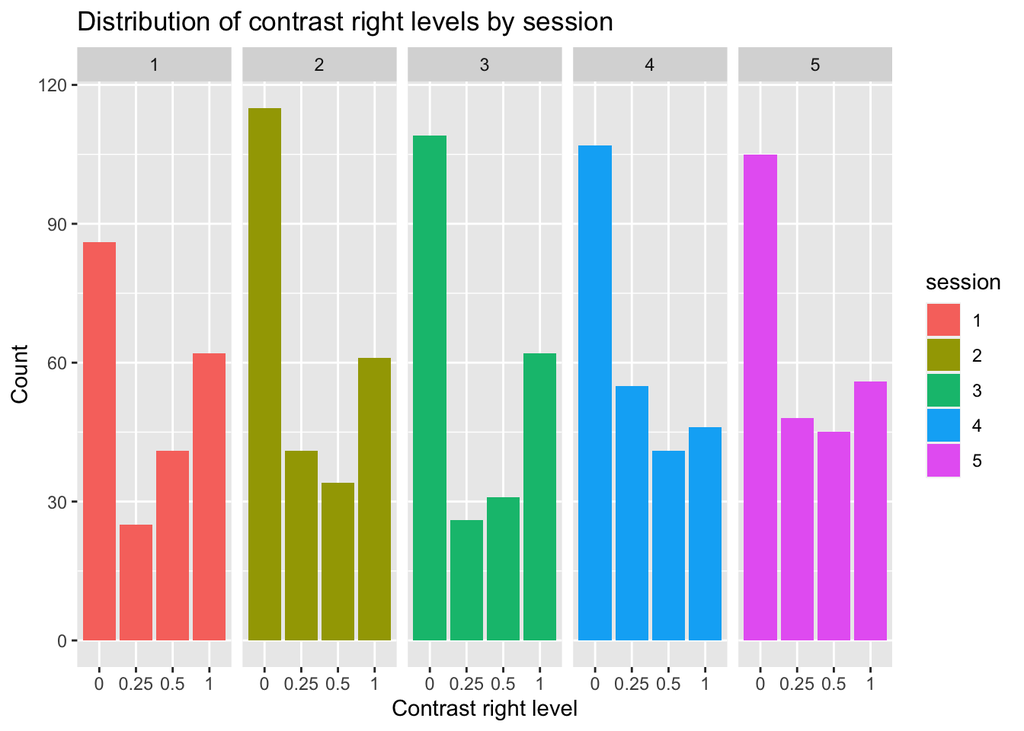

**Figure 1:** Distribution of contrast right levels by session

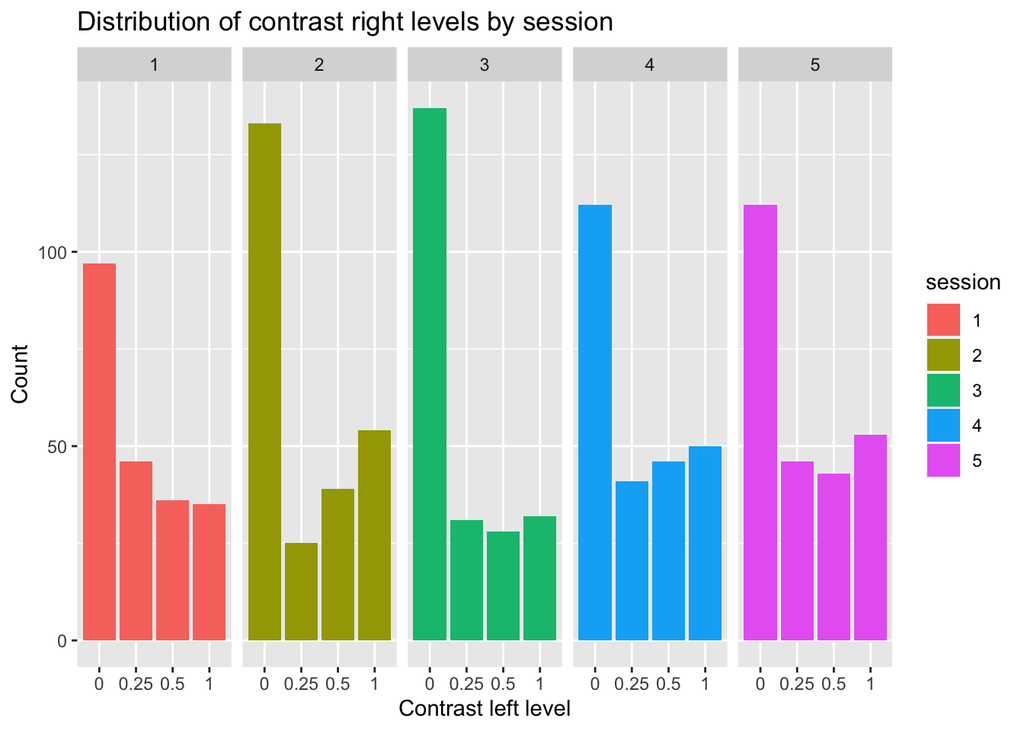

**Figure 2:** Distribution of contrast left levels by session

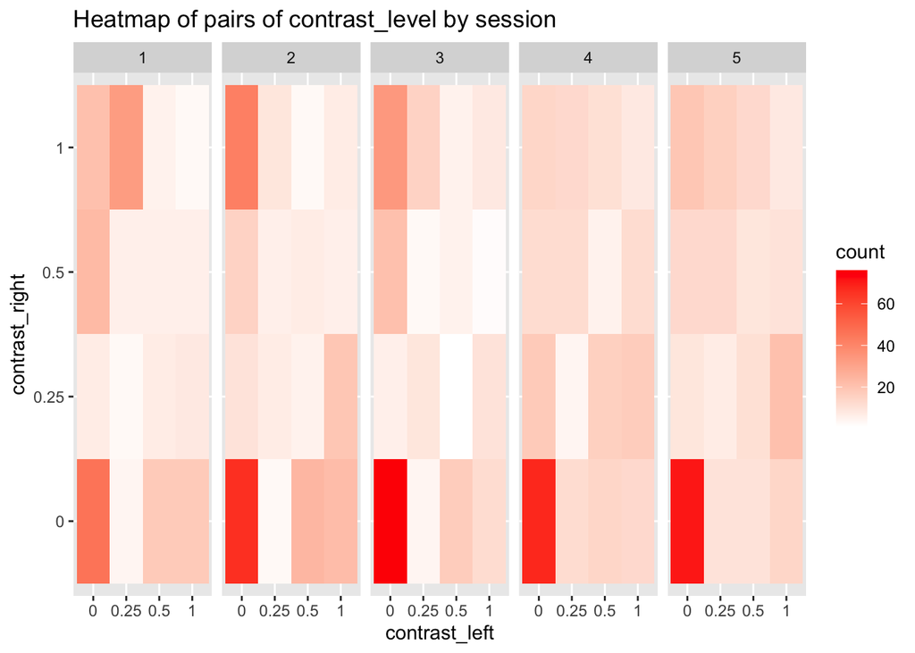

**Figure 3:** Heat Map of contrast left and contrast right pairs

For the numeric variables spks and time, these two variables keep track of the activity of the neurons for the mouse in each trial. However it’s difficult to take these two variables as response variable with a large number of data. Furthermore, the number of neurons varies across sessions, so it is important to consider the average firing rate for each trial as a single observation. Since the spks variable uses 1 to represent the number of spikes and has many zero values in each trial, it is appropriate to use the mean firing rate as our response variable. This can be calculated using the following equation:
$$Mean\ Firing\ Rate = \frac{sum\ of\ the\ number\ of\ spks\ each\
trial}{(number\ of\ neurons\ each\ trail)*0.4\ seconds}$$
By computing the mean firing rate of each trial across all neurons within a given time interval, we effectively reduce the two variables related to each individual neuron into a single variable that represents the overall neural activity for each trial in a session. This reduction in dimensional allows for a more understandable representation of the data while still retaining essential information about the firing patterns of the neurons in response to visual stimuli. In a addition, the mean firing rate is a reliable measure of the activity that can offer valuable insights into the underlying neural activities involved in visual stimuli and decision-making behavior in the context of this study. Based on the density curves of firing rates(Figure 4) for each session, it appears that the patterns of firing rate in Sessions 4 and 5 exhibit similarity to each other, which is a plausible observation given that these sessions were obtained from the same mouse. Given that the neurons in the visual cortex respond to visual stimuli, it is likely that they would exhibit similar activity patterns in response to similar visual inputs. Meanwhile, the plot shows that the mean firing rate for the second mouse, Forssmann is smaller than the firing rate for the first mouse, Cori. The observation may illustrate that the neuron activity of the second mouse is less active than the first mouse.

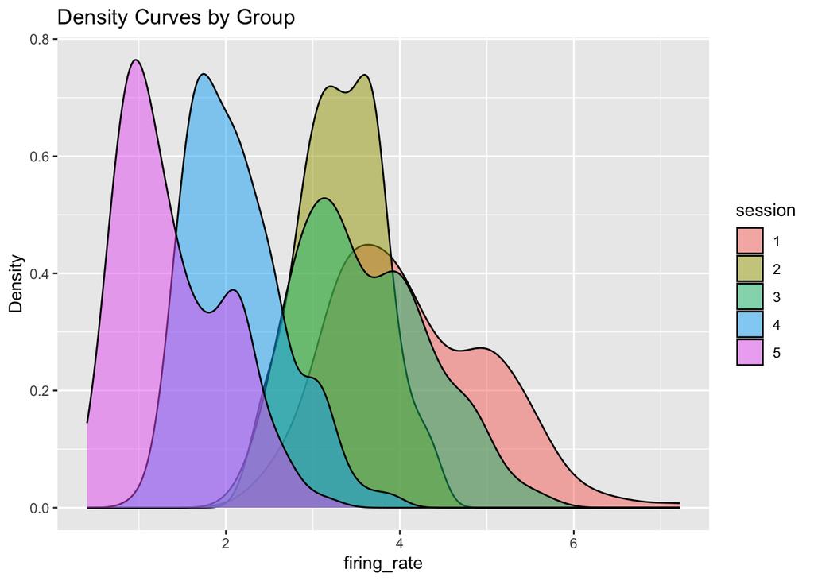

**Figure 4:** Density of mean firing rate by session

Having understood the individual variables mentioned earlier, the corresponding dataset for building the model is presented in the table below, with each row representing a single trial and a total of 1196 trials for this project. The next step is to examine the interrelationship between the variables.

| contrast_right | contrast_left | feedback_type | firing_rate | session |
| --- | --- | --- | --- | --- |
| 0 | 1 | 1 | 6.1938202247191 | 1 |
| 0.5 | 0 | 1 | 4.08707865168539 | 1 |
| 0.5 | 1 | 1 | 5.87078651685393 | 1 |
| 0 | 0 | 1 | 4.08707865168539 | 1 |
| 1 | 0.5 | -1 | 5.53370786516854 | 1 |
| 0 | 0 | -1 | 3.55337078651685 | 1 |
| 0 | 0 | -1 | 3.79213483146067 | 1 |
| 0 | 0 | -1 | 3.9747191011236 | 1 |
| 0 | 0 | 1 | 3.17415730337079 | 1 |
| 0.5 | 1 | 1 | 6.65730337078652 | 1 |

[output cut: 1186 more lines]

From the main effect plot between contrast_right and firing_rate for different sessions(Figure 5), the general trend shows that the mean firing rate tends to increase with an increase in the contrast right level, except for session 1. The observations is somewhat easy to understand, a higher level of stimuli may lead to an active activity of neurons for mouse. In terms of the left contrast(Figure 6), the trend shows more variations rather than a monotonic increase or decrease. The dissimilarity may indicate that there are interactions between contrast_left and contrast_right. By applying the interaction main effect plot for different sessions(Figure 7), the lines of session 1 is somewhat parallel to each other and there are dissimilarity exists for other sessions. Based on the plots, there appears to be an interaction between the left contrast and right contrast. However, it is also plausible that the dissimilarity is due to the asymmetry of the mouse’s brain. It is possible that the activities of neurons for the left visual field and right visual field in the mouse’s brain are distinct, leading to a difference in the patterns of mean firing rate. So further interpretation is needed for whether include the interaction part or not.

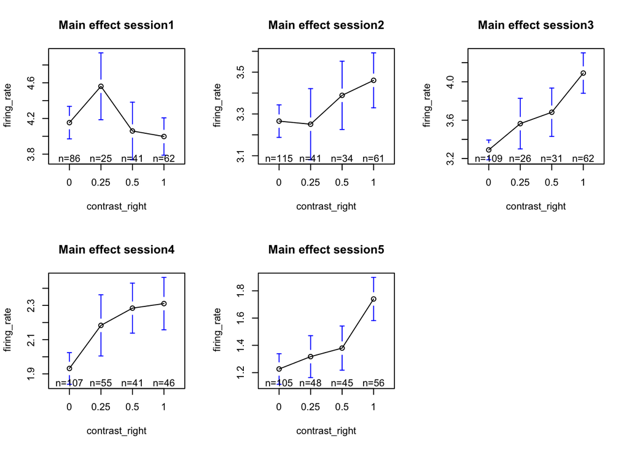

**Figure 5:** Main effect plot of contrast_right and firing_rate by session

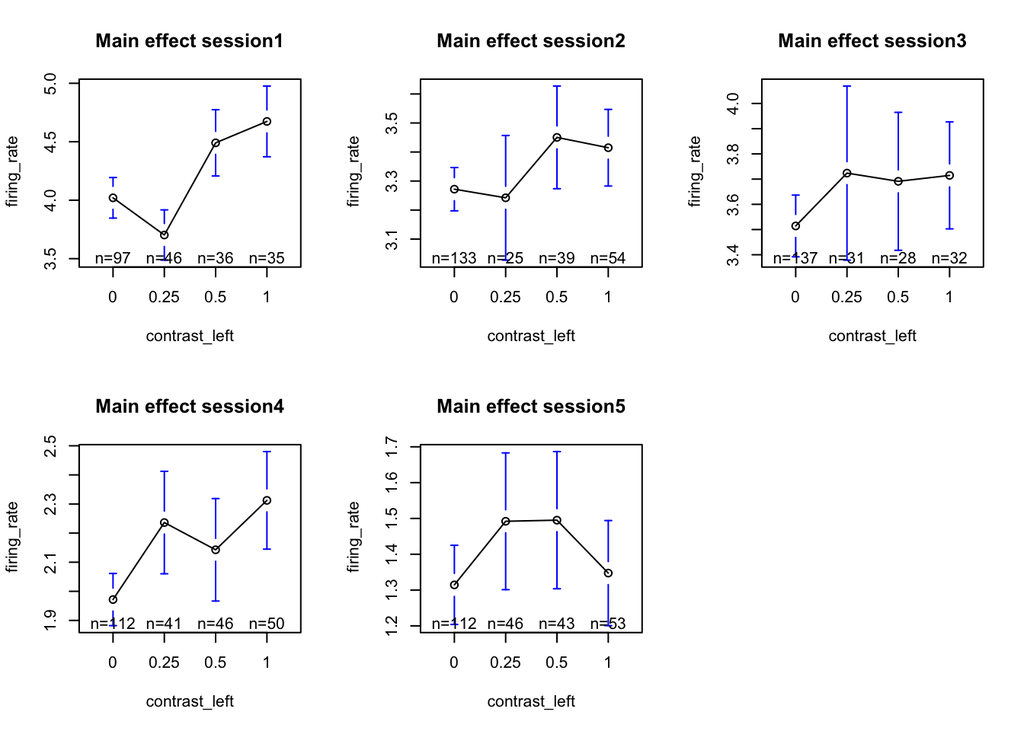

**Figure 6:** Main effect plot of contrast_left and firing_rate by session

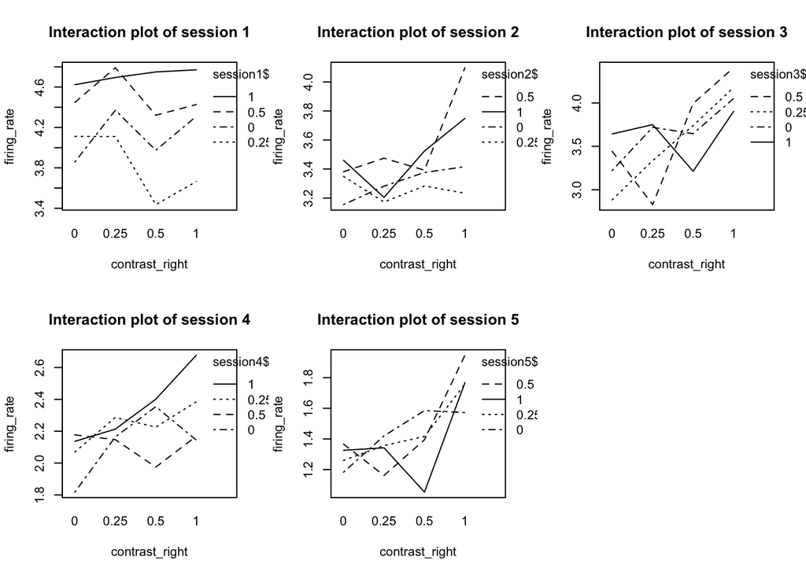

**Figure 7:** Interaction effect plot of contrast_left and contrast_right by sessions

# Inferential analysis

# Sensitivity analysis

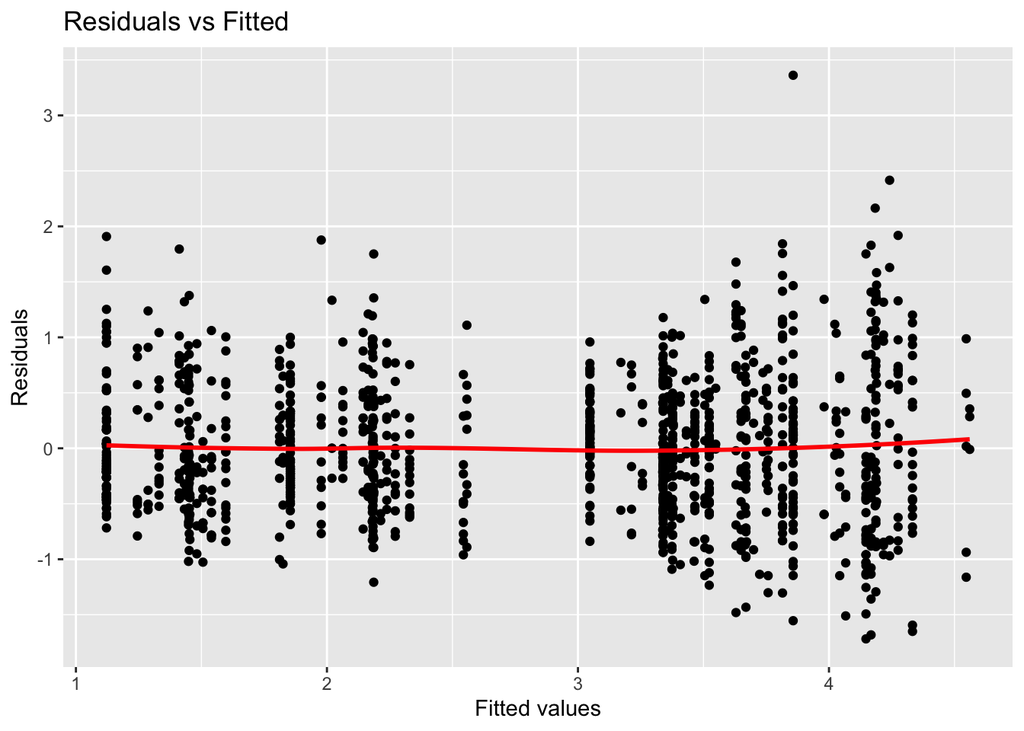

**Figure 8:** Residual vs. fitted Plot

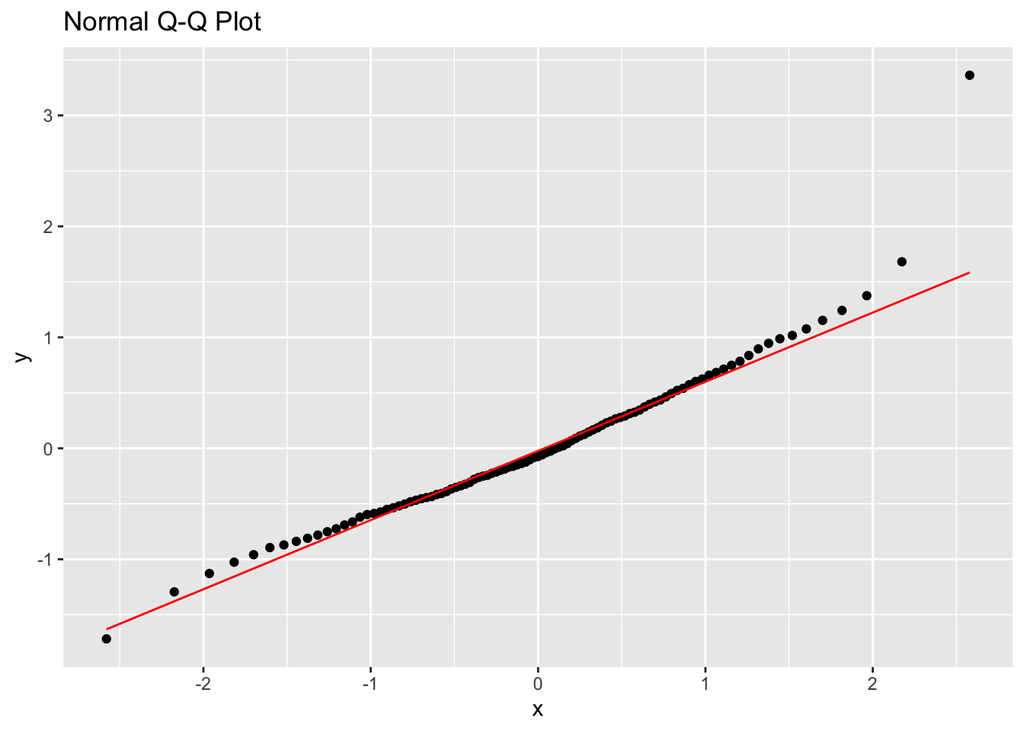

**Figure 9:** Normal Q-Q Plot

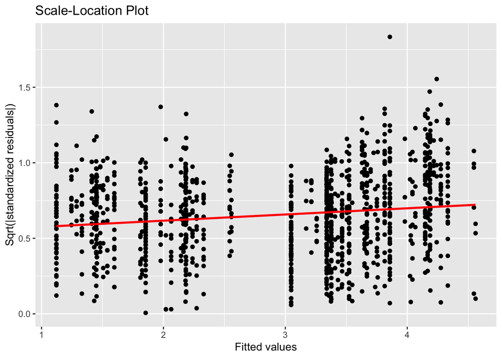

**Figure 10:** Scale-Location Plot

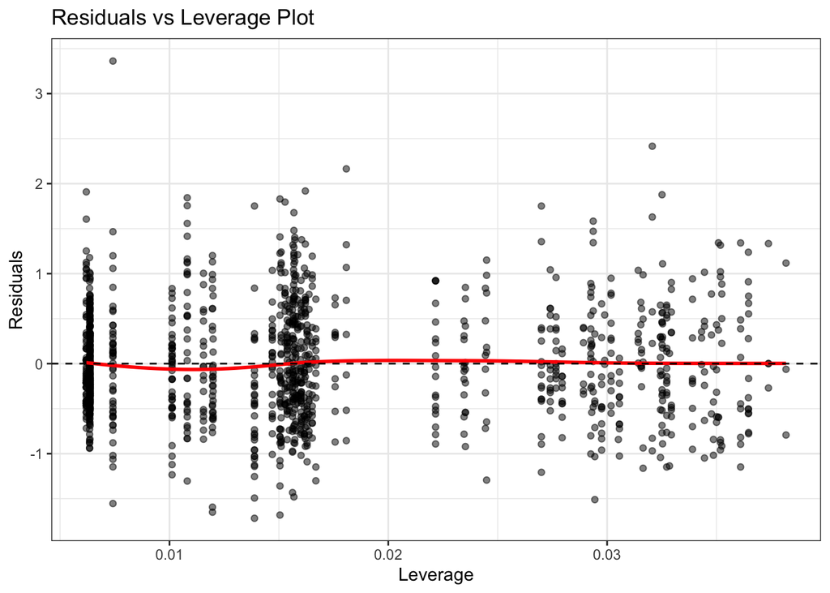

**Figure 11:** Residuals vs Leverage Plot

# Prediction

For the second purpose of the project, we choose to use the method of logistic regression to predict the outcome of each trial using the neural activities which is the mean firing rate from our previous analysis and stimuli which is the contrast_left and contrast_right. Before building a model to predict the feedback type, we first analyze its distribution in the data set to gain a general understanding of this variable. Referring to the project description, the mice have three options to make a choice. Firstly, if the contrast levels of the left and right screens are not equal, the mouse will receive a water reward for choosing the screen with higher contrast. For instance, if the right screen has a higher contrast level(0.5) than the left one(0), the mouse will be rewarded if it turns the wheel to the right screen but penalized if it turns the wheel to the left. Secondly, if there are no stimuli presented, meaning the contrast_left and contrast_right levels are both 0, the mouse will receive a reward for holding the wheel still for 1.5 seconds, whereas it will be penalized if it moves the wheel. Lastly, if the contrast levels of the two screens are equal but non-zero, the mouse will receive a reward for making any choice of screen, and will be penalized if it does not move the wheel at all. Based on Figure 12, which displays the distribution of feedback types for the five sessions, we can observe that the number of successful feedback trials is generally higher than the number of failed ones in all sessions. Additionally, it’s crucial to understand the relationship between feedback_type and (contrast_left, contrast_right) pairs. From the heat map (Figure 13), we can see that the proportion of successful trials is higher than the proportion of failed trials when the difference between contrast levels of the two screens is large. However, when the level of contrast_left is larger than contrast_right, but the difference in contrast is not significant, the mouse may have a weaker ability to distinguish the visual stimuli, in other word, may have larger propabilities for getting penalty.This finding may be due to the position of the neurons in the mice brain, which may have different abilities to react to the stimuli from the left and right eyes.

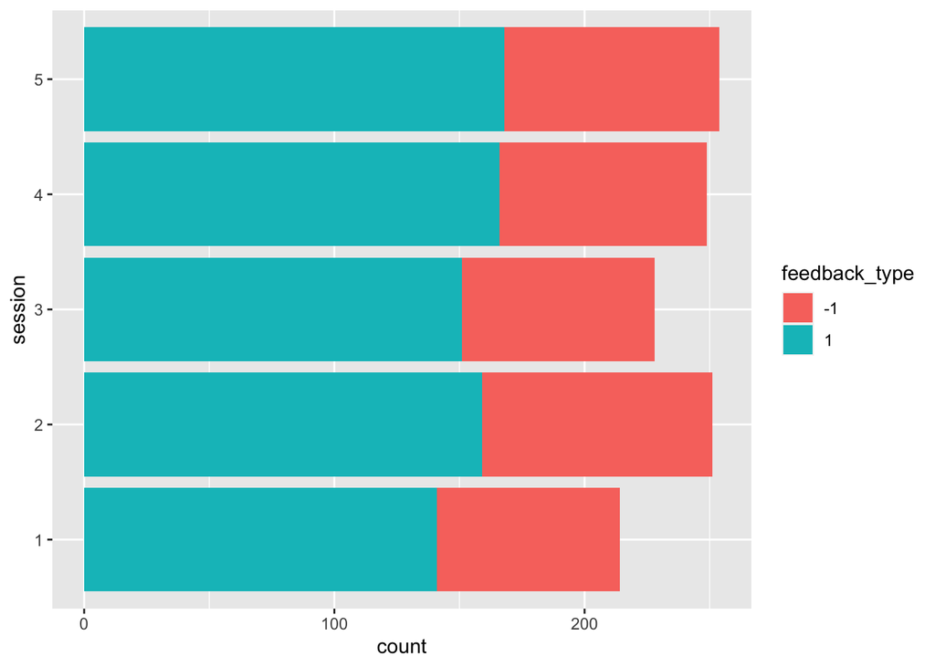

**Figure 12:** Feedback_type for different sessions

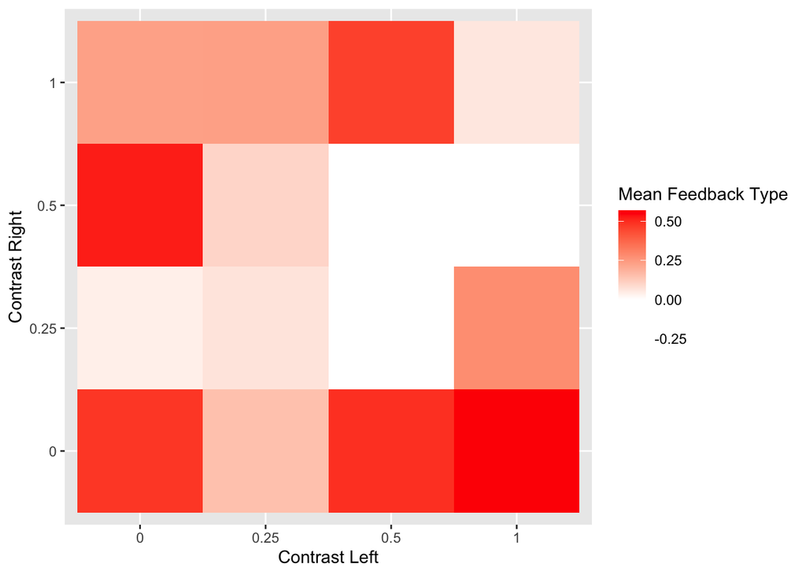

**Figure 13:** Heatmap for the mean feedback_type for different pairs of (contrast_left,contrast_right)

According to the density curve of firing rate by feedback type, we can observe that the majority of mean firing rates for both successful and failed trials fall between 0 and 6. This plot suggests that regardless of the mouse’s response, its brain activity is relatively similar. However, the mouse may have larger probability for making a right choice when the mean firing rate is larger than 4.

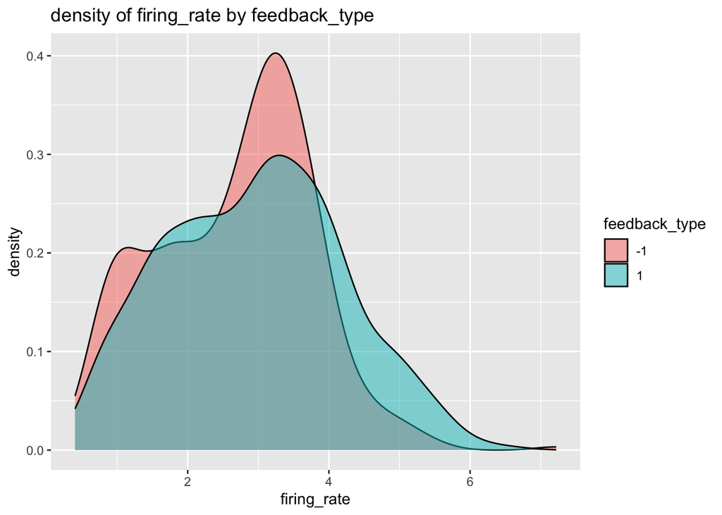

**Figure 13:** density of firing_rate by feedback_type

# Discussion

# Reference

Steinmetz, N.A., Zatka-Haas, P., Carandini, M. et al. Distributed coding of choice, action and engagement across the mouse brain. Nature 576, 266–273 (2019). https://doi.org/10.1038/s41586-019-1787-x